# Statistical Methods for Reliability Data

Chapter 1 - Reliability Concepts and Reliability Data

W. Q. Meeker and L. A. Escobar

2019-06-07

# In This echapter…

An overview of the `SMRD` package features

An overview of working with `life.data` objects

- Creating `life.data` objects with `frame.to.ld()`
- Viewing and subsetting elements
- Plotting `life.data` objects

## `SMRD` Package Features

SMRD is designed to easily return estimation/prediction results for many types of failure data

- Multiple failure events
- Censored data (right, left, and interval censoring)
- Truncated data (right, left, and interval truncation)
- Failure data with explanatory variables (failure-time regression)
- Repeated measures degradation data (linear & non-linear mixed effects)
- Repairable system failure data (recurring events)
- Physical/performance degradation data
- Failure data with prior information (Bayesian reliability)
- Reliability growth test data
- Reliability test simulations

`SMRD` facilitates minimal data pre-processing through flexible event definitions

- Organizations often use different terms to describe the same event
  - ‘Failure’ = ‘Failed’ = ‘Fail’ = ‘dead’ = ‘died’
- ‘right’ = ‘rcensored’ = ‘suspended’ = ‘alive’
- ‘left’ = ‘doa’ = ‘lcensored’
- ‘interval’ = ‘int’ = ‘icensored’ = ‘grouped’

Many applications use ambiguous numerical codes to represent these events

- Often, the numerical event codes used by one software package don’t coincide with those used by other packages
- `SMRD` allows for flexible event definitions to utilize the data as-is
- Event definitions can even be mixed
- `SMRD` event definitions easily mapped to `survival` numeric definitions

The table below shows the default `SMRD` default event definitions

```r
fail <- strsplit(SMRDOptionsDefaults()$SMRD.F,  split = ',')[[1]]
left <- strsplit(SMRDOptionsDefaults()$SMRD.Lc, split = ',')[[1]]
righ <- strsplit(SMRDOptionsDefaults()$SMRD.Rc, split = ',')[[1]]
intv <- strsplit(SMRDOptionsDefaults()$SMRD.Ic, split = ',')[[1]]
lengths <- lapply(X = list(fail,left,righ,intv),
                  FUN = function(x) length(x))

Length <- max(unlist(lengths))

fails <- c(fail, rep('', Length-length(fail)))
lefts <- c(left, rep('', Length-length(left)))
righs <- c(righ, rep('', Length-length(righ)))
intvs <- c(intv, rep('', Length-length(intv)))
dats <- data.frame(fails,lefts,righs,intvs)
colnames(dats) <- c('Failed',
                    'Left-censored',
                    'Right-censored',
                    'Interval-censored')
DT::datatable(dats, options = list(pageLength = 20))
```

|  | Failed | Left-censored | Right-censored | Interval-censored |
| --- | --- | --- | --- | --- |
| 1 | event | l | a | b |
| 2 | exact | l-censored | alive | bin |
| 3 | d | left-censored | c | i |
| 4 | dead | left | censor | interval |
| 5 | died | leftcensored | censored | i-censored |
| 6 | f | start | end | intervalcensored |
| 7 | fail | mstart | mend | interval-censored |
| 8 | failed | 3 | noreport | 4 |
| 9 | failure |  | r |  |
| 10 | report |  | r-censored |  |

[output cut: 10 more lines]

- Many of these data sets still need to be documented
- A list of these data sets is returned using `data(package = "SMRD")`
- Likewise, the names and descriptions of the data sets is shown in the table below

```r
DT::datatable(as.data.frame(data(package = 'SMRD')$results[,c(-2)]))
```

|  | Package | Item | Title |
| --- | --- | --- | --- |
| 1 | SMRD | adhesivebondc | Adhesive bonded power element test |
| 2 | SMRD | adhesivestrength | Accelerated adhesive creep test |
| 3 | SMRD | alloya | Fatigue crack growth in an unknown metallic alloy. |
| 4 | SMRD | alloyc | Metal alloy tensile strength test |
| 5 | SMRD | amsaaexactfail | AMSAA reliability growth test |
| 6 | SMRD | amsaawindow1 |  |
| 7 | SMRD | amsaawindow2 |  |
| 8 | SMRD | appliancea | Appliance cord failures |
| 9 | SMRD | applianceb | Appliance-B failures (multiple data sources) |
| 10 | SMRD | aprel72 | ##### |

[output cut: 106 more lines]

# Analyzing the Leiblien-Zelen Data Set `lzbearing`

Overview of the data set

- Complete data set 23 observations
- Most basic of the data sets included in the package

```r
DT::datatable(lzbearing, options = list(pageLength = 8))
```

|  | megacycles |
| --- | --- |
| 1 | 17.88 |
| 2 | 28.92 |
| 3 | 33 |
| 4 | 41.52 |
| 5 | 42.12 |
| 6 | 45.6 |
| 7 | 48.4 |
| 8 | 51.84 |
| 9 | 51.96 |
| 10 | 54.12 |

[output cut: 13 more lines]

- Many functions in the SMRD package require a `life.data` object. `life.data` objects are created using the function `frame.to.ld`.

```r
lzbearing.ld <- frame.to.ld(lzbearing,
                            response.column = 1,
                            time.units = "Megacycles")
```

- Once the `life.data` has been created, several plots and values can be produced

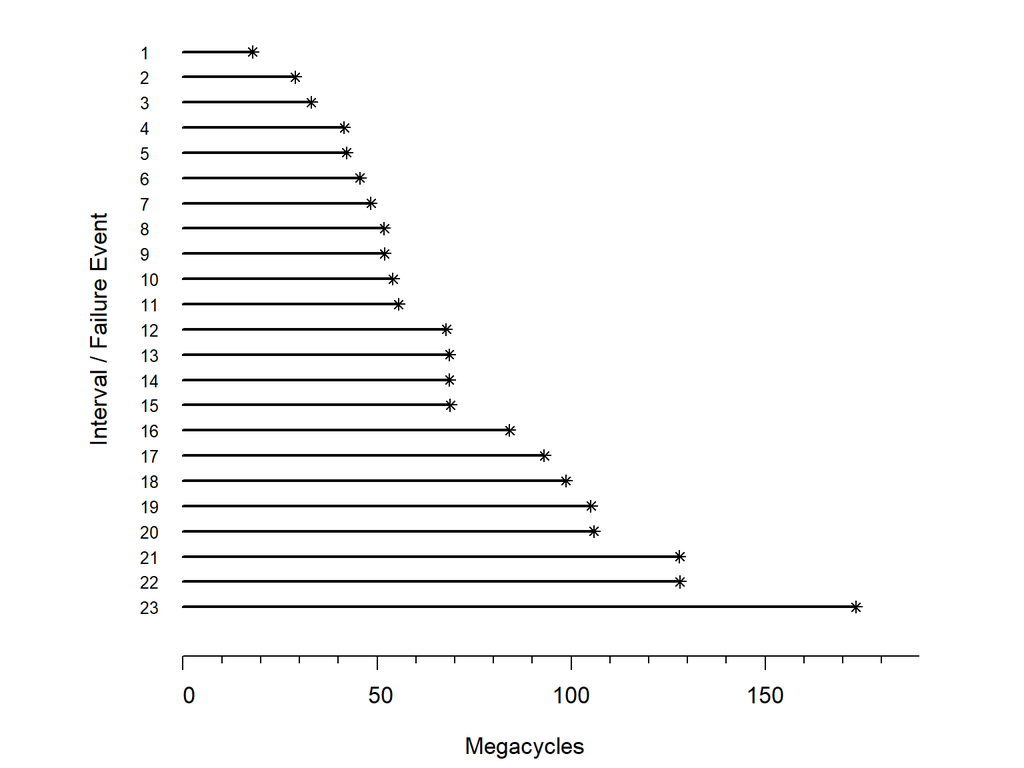

```r
event.plot(lzbearing.ld)
```

```r
summary(lzbearing.ld)
```

```
$`Summary of lzbearing`

    Rows in data matrix:          23
         Response units:  Megacycles
       Minimum response:       17.88
       Maximum response:       173.4
      Cases in data set:          23
     Exact observations:          23
 Truncation information:        none
  Explanatory variables:        none
```

```r
print(lzbearing.ld)
```

```
Data from  lzbearing
   megacycles
1       17.88
2       28.92
3       33.00
4       41.52
5       42.12
6       45.60
7       48.40
8       51.84
9       51.96
10      54.12
11      55.56
12      67.80
13      68.64
14      68.64
15      68.88
16      84.12
17      93.12
18      98.64
19     105.12
20     105.84
21     127.92
22     128.04
23     173.40
```

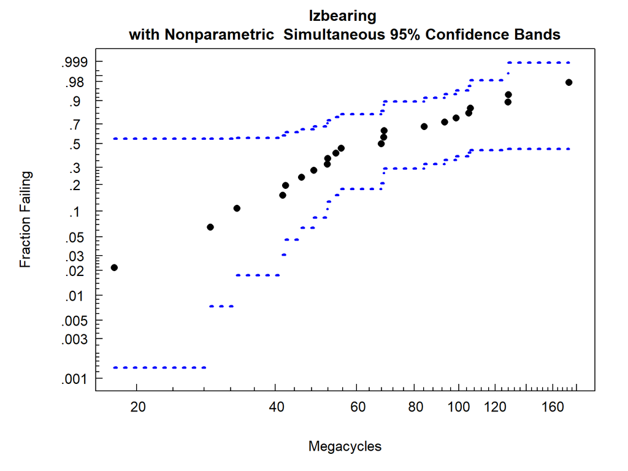

```r
plot(lzbearing.ld, distribution = "weibull")
```

Many other plots and numerical results can also be easily returned as shown in the next example

- Plots
  - Nonparametric CDF plots
  - Parametric CDF plots
  - ML CDF and hazard plots
  - Explanatory variable plots
  - Multi-failure mode plots
  - Relative likelihood surfaces
  - Relative likelihood curves
- Numerical results
  - $F(t)$ at specified values of $t$
  - $h(t)$ at specified values of $t$
  - $t^{-1}(p)$ at specified values of $p$
  - ML parameter estimates and standard errors
  - Logit and log transformed confidence intervals (pointwise and simultaneous)

# Example: Analyzing the `shockabsorber` dataset

## Dataset: `shockabsorber`

- This example demonstrates some of the `SMRD` functions to analyze the shockabsorber dataset used throughout the text

```r
shockabsorber
```

```
   miles     mode    event
1   6700    Mode1  Failure
2   6950 Censored Censored
3   7820 Censored Censored
4   8790 Censored Censored
5   9120    Mode2  Failure
6   9660 Censored Censored
7   9820 Censored Censored
8  11310 Censored Censored
9  11690 Censored Censored
10 11850 Censored Censored
11 11880 Censored Censored
12 12140 Censored Censored
13 12200    Mode1  Failure
14 12870 Censored Censored
```

[output cut: 24 more lines]

- Creating the `life.data` object

```r
shock.ld <- frame.to.ld(frame = shockabsorber,
                        response.column = 1,
                        failure.mode.column = 2,
                        censor.column = 3,
                        time.units = 'Kilometers')
```

- Nonparametric & Parametric CDF plots

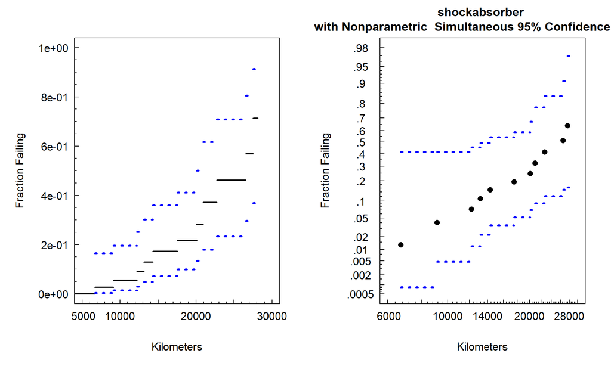

```r
plot(shock.ld)
plot(shock.ld, distribution = 'lognormal')
```

- Maximum likelihood plots $F(t)$ & $h(t)$

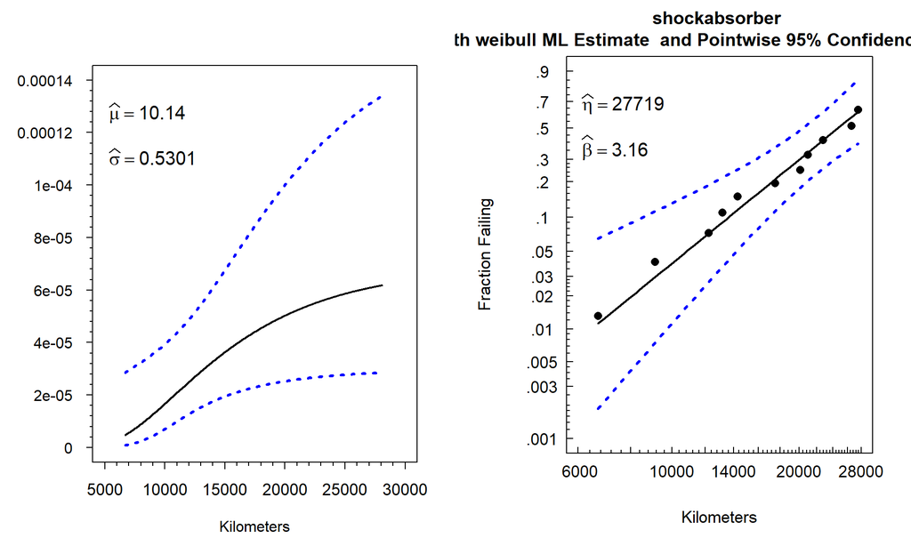

```r
mlehazplot(shock.ld,  distribution = 'lognormal', param.loc = 'topleft')
mleprobplot(shock.ld, distribution = 'weibull', param.loc = 'topleft')
```

- Relative likelihood surface plots

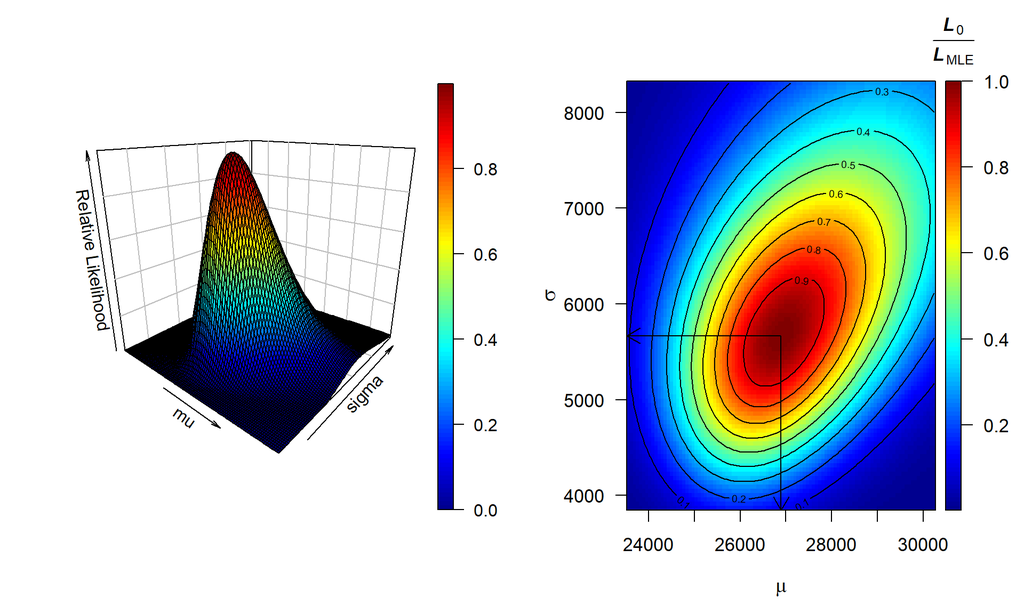

```r
simple.contour(shock.ld, distribution = 'sev', threeD = T, original.par = F)
simple.contour(shock.ld, distribution = 'sev', show.confidence = F, zoom = 1.75)
```

- Maximum likelihood estimate results

```r
(print(mlest(shock.ld, distribution = 'weibull')))
```

```
$ll.text
[1] "The maximum value of the log-likelihood function for the shockabsorber  (assuming the weibull distribution is correct) was found to be -124"

$ll.value
[1] "-124"

$mttf.text
[1] "The ML estimate of mean time to failure (MTTF) for the shockabsorber (assuming the weibull distribution is correct) was found to be 24812 Kilometers. An approximate 95% confidence interval on the MTTF is [20202, 30472]."

$mttf.value
 mttf
24812

$mle.table
                      MLE   Std.Err.  95% Lower  95% Upper
mu             1.0230e+01 1.0989e-01    10.0145 1.0445e+01
sigma          3.1641e-01 7.3165e-02     0.2011 4.9783e-01
Weibull (eta)  2.7719e+04 3.0460e+03 22347.7697 3.4380e+04
Weibull (beta) 3.1605e+00 7.3082e-01     2.0087 4.9726e+00

$vcv.matrix
             mu     sigma
mu    0.0120759 0.0039904
sigma 0.0039904 0.0053532

$param.corr.matrix
           mu   sigma
mu    1.00000 0.49631
sigma 0.49631 1.00000

$failure.probabilities
      Kilometers     Fhat Std.Err. 95% Lower 95% Upper
 [1,]       6000 0.007902 0.007815  0.001133   0.05403
 [2,]       8000 0.019500 0.015360  0.004136   0.08934
 [3,]      10000 0.039080 0.024800  0.011150   0.13220
 [4,]      12000 0.068480 0.035220  0.024650   0.18260
 [5,]      14000 0.109100 0.045740  0.047150   0.24120
 [6,]      16000 0.161500 0.055930  0.080400   0.30920
 [7,]      18000 0.225500 0.066050  0.124400   0.38830
 [8,]      20000 0.299900 0.077040  0.176900   0.47940
```

[output cut: 23 more lines]

```
$hazard.table
  Time     Hazard   StdError  95% lower  95% upper
  6000 4.1791e-06 3.2421e-06 9.1355e-07 1.9118e-05
  8000 7.7805e-06 4.5732e-06 2.4586e-06 2.4622e-05
 10000 1.2600e-05 5.7399e-06 5.1597e-06 3.0771e-05
 12000 1.8683e-05 6.8460e-06 9.1105e-06 3.8314e-05
 14000 2.6067e-05 8.2448e-06 1.4023e-05 4.8453e-05
 16000 3.4784e-05 1.0488e-05 1.9263e-05 6.2810e-05
 18000 4.4863e-05 1.4092e-05 2.4239e-05 8.3036e-05
 20000 5.6331e-05 1.9364e-05 2.8718e-05 1.1050e-04
 22000 6.9211e-05 2.6447e-05 3.2728e-05 1.4636e-04
 24000 8.3525e-05 3.5428e-05 3.6372e-05 1.9181e-04
 26000 9.9293e-05 4.6385e-05 3.9744e-05 2.4806e-04
 28000 1.1653e-04 5.9400e-05 4.2911e-05 3.1647e-04
 30000 1.3527e-04 7.4557e-05 4.5921e-05 3.9844e-04
```

# Example: Nelson’s Super-Alloy Data Set `superalloy`

```r
superalloy.ld <- frame.to.ld(superalloy,
                             response.column = 1,
                             censor.column = 2,
                             x.columns = c(5,6,4),
                             time.units = "Kilocycles")

summary(superalloy.ld)
```

```
$`Summary of superalloy`

         Rows in data matrix:          26
              Response units:  Kilocycles
            Minimum response:       5.733
            Maximum response:      211.63
           Cases in data set:          26
          Exact observations:          22
 Right censored observations:           4
      Truncation information:        none

$`Summary of numeric columns in X matrix`
 predictor     min      max     mean       sd       cv
   pstress 80.3000 145.9000 102.4654 20.68201 0.201844
  lpstress  4.3858   4.9829   4.6112  0.19192 0.041620
```

[output cut: 57 more lines]

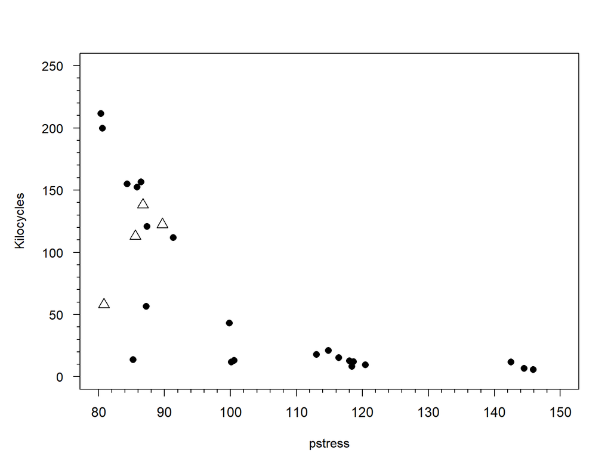

```r
censored.data.plot(superalloy.ld,
                   explan.var = 1)
```

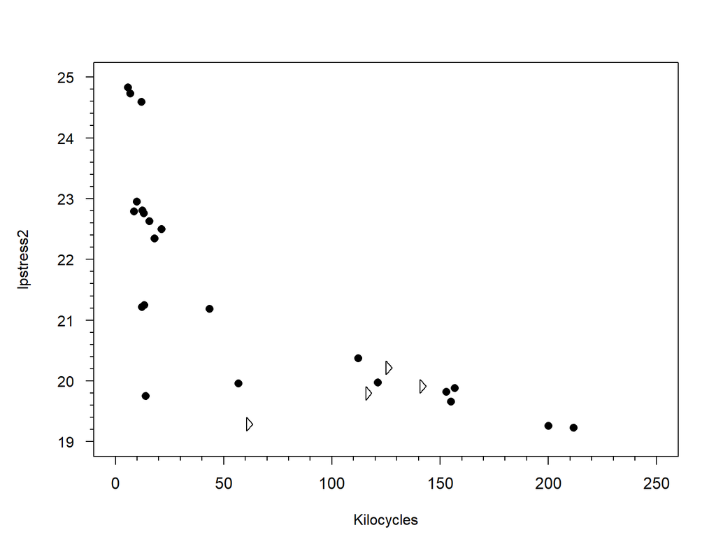

```r
censored.data.plot(superalloy.ld,
                   explan.var = 3,
                   response.on.yaxis = F)
```

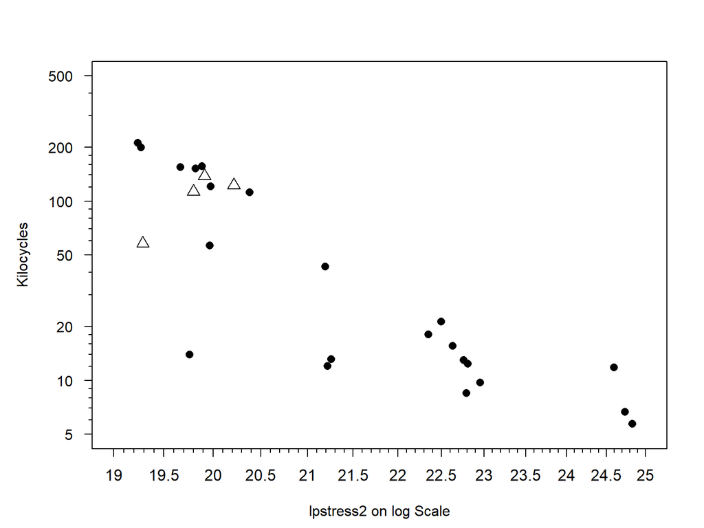

```r
censored.data.plot(superalloy.ld,
                   explan.var = 3,
                   x.axis = "log",
                   y.axis = "log")
```

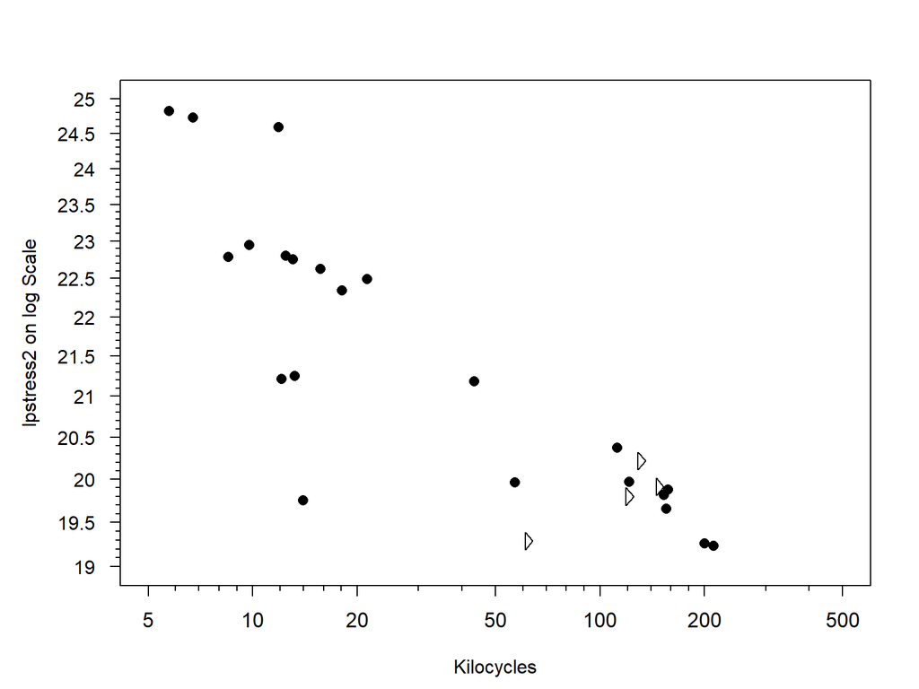

```r
censored.data.plot(superalloy.ld,
                   explan.var = 3,
                   response.on.yaxis = F,
                   x.axis = "log",
                   y.axis = "log")
```